# German Electricity Data :electric_plug:

- Data Source: [SMARD Web Portal](https://www.smard.de/)
- Task: forecasting (using the past to predict the future)
- Language: R

## First steps:

- load the data (with appropriate column types) :heavy_check_mark:
- split the data into train/val/test sets :heavy_check_mark:
- plot the time series (at different temporal resolution) :heavy_check_mark:
- calculate the mean production per month :heavy_check_mark:
- is there a seasonal pattern (what kinds of seasonalities)
- make a prediction for the validation set
- evaluate the quality of the prediction

```r
library(tidyverse)
```

```r
theme_set(theme_light())
```

```r
set.seed(42)
"Simon Maik Max Dharu Robin" %>%  str_split(" ") %>% unlist %>% sample %>% str_c(collapse=" → ")
```

'Simon → Robin → Dharu → Max → Maik'

## 1. Data loading

- load the hourly data from the file `Realisierte_Erzeugung_201501010000_202305301300_Stunde.csv` as a table into R :heavy_check_mark:
- make sure, that data is interpreted and typed correctly :heavy_check_mark:
- clean header names :heavy_check_mark:
- create column `Time` containing the combined info from `Datum` and `Anfang`

```r
data <- read_csv2(
    "../data_dojo_22/Realisierte_Erzeugung_201501010000_202305301300_Stunde.csv",
    col_types=cols(`Datum` = col_date("%d.%m.%Y")),
    na="-"
)
```

```
ℹ Using "','" as decimal and "'.'" as grouping mark. Use `read_delim()` for more control.
```

```r
colnames(data) <- colnames(data) %>% str_remove(" \\[.*") %>% str_replace(" ","_")
```

### 2<sup>nd</sup> session

- Create `Time` column
- Split into training/validation/test set
- Plot the training set with hourly resolution
- Aggregate by day/month
- Plot aggregated data

**Bonus task**

- did you observe something peculiar with dates and times?
- look at the hourly data of 2017-10-29 for an example
- what happened there?
- are there more days with a similar "problem"?
- is this a problem?
- how can we solve this?

```r
data <- data %>%
    mutate(Time=Datum+hours(hour(Anfang)))
```

```r
data
```

A tibble: 73716 × 16

| Datum <date> | Anfang <time> | Ende <time> | Biomasse <dbl> | Wasserkraft <dbl> | Wind_Offshore <dbl> | Wind_Onshore <dbl> | Photovoltaik <dbl> | Sonstige_Erneuerbare <dbl> | Kernenergie <dbl> | Braunkohle <dbl> | Steinkohle <dbl> | Erdgas <dbl> | Pumpspeicher <dbl> | Sonstige_Konventionelle <dbl> | Time <dttm> |
| --- | --- | --- | --- | --- | --- | --- | --- | --- | --- | --- | --- | --- | --- | --- | --- |
| 2015-01-01 | 00:00:00 | 01:00:00 | 4024.25 | 1158.25 | 516.50 | 8128.00 | 0.00 | 133.00 | 10710.50 | 15687.25 | 3219.75 | 1226.25 | 1525.75 | 4909.25 | 2015-01-01 00:00:00 |
| 2015-01-01 | 01:00:00 | 02:00:00 | 3982.75 | 1188.00 | 516.25 | 8297.50 | 0.00 | 122.50 | 11086.25 | 15321.75 | 2351.25 | 870.75 | 1079.25 | 4932.75 | 2015-01-01 01:00:00 |
| 2015-01-01 | 02:00:00 | 03:00:00 | 4019.50 | 1139.25 | 514.00 | 8540.00 | 0.00 | 93.00 | 11026.25 | 14817.50 | 2227.00 | 809.50 | 787.00 | 5041.75 | 2015-01-01 02:00:00 |
| 2015-01-01 | 03:00:00 | 04:00:00 | 4040.75 | 1122.50 | 517.75 | 8552.00 | 0.00 | 86.50 | 11027.75 | 14075.00 | 2339.75 | 821.00 | 287.75 | 5084.00 | 2015-01-01 03:00:00 |
| 2015-01-01 | 04:00:00 | 05:00:00 | 4037.75 | 1112.00 | 519.75 | 8643.50 | 0.00 | 86.50 | 10962.25 | 14115.00 | 2461.50 | 831.25 | 346.75 | 5070.75 | 2015-01-01 04:00:00 |
| 2015-01-01 | 05:00:00 | 06:00:00 | 4028.25 | 1107.75 | 520.00 | 8711.75 | 0.00 | 86.75 | 10696.00 | 13474.25 | 2217.75 | 851.00 | 765.50 | 5096.75 | 2015-01-01 05:00:00 |
| 2015-01-01 | 06:00:00 | 07:00:00 | 4013.25 | 1111.75 | 521.50 | 9167.25 | 0.00 | 87.00 | 10299.50 | 12403.75 | 2373.25 | 868.25 | 414.50 | 5153.00 | 2015-01-01 06:00:00 |
| 2015-01-01 | 07:00:00 | 08:00:00 | 4012.75 | 1113.75 | 520.25 | 9811.00 | 0.00 | 87.00 | 10035.25 | 12062.50 | 2491.00 | 876.00 | 582.50 | 5161.00 | 2015-01-01 07:00:00 |
| 2015-01-01 | 08:00:00 | 09:00:00 | 3999.75 | 1107.50 | 525.25 | 9683.00 | 53.00 | 87.00 | 10245.75 | 12405.00 | 2530.25 | 888.25 | 750.50 | 5393.50 | 2015-01-01 08:00:00 |
| 2015-01-01 | 09:00:00 | 10:00:00 | 4016.25 | 1121.00 | 527.00 | 9501.75 | 773.25 | 85.75 | 10060.25 | 12798.75 | 2386.25 | 891.50 | 387.00 | 5884.00 | 2015-01-01 09:00:00 |
| 2015-01-01 | 10:00:00 | 11:00:00 | 4007.75 | 1122.00 | 525.00 | 10025.00 | 2116.75 | 82.00 | 10082.25 | 12728.50 | 2557.00 | 888.25 | 176.25 | 6064.00 | 2015-01-01 10:00:00 |
| 2015-01-01 | 11:00:00 | 12:00:00 | 4011.75 | 1146.25 | 527.25 | 10862.50 | 3364.25 | 82.00 | 9949.00 | 12451.00 | 2657.75 | 876.50 | 884.50 | 5914.75 | 2015-01-01 11:00:00 |
| 2015-01-01 | 12:00:00 | 13:00:00 | 4014.00 | 1139.75 | 527.75 | 11575.25 | 4198.25 | 82.00 | 10119.00 | 12464.50 | 2937.75 | 874.25 | 705.00 | 5778.25 | 2015-01-01 12:00:00 |
| 2015-01-01 | 13:00:00 | 14:00:00 | 4005.50 | 1128.00 | 527.75 | 11977.25 | 3500.50 | 84.50 | 10453.50 | 12417.75 | 2810.25 | 883.50 | 967.25 | 5808.75 | 2015-01-01 13:00:00 |
| 2015-01-01 | 14:00:00 | 15:00:00 | 4024.25 | 1154.75 | 524.75 | 11396.00 | 2278.75 | 87.00 | 10828.25 | 12621.50 | 2664.00 | 890.25 | 1176.25 | 5842.50 | 2015-01-01 14:00:00 |
| 2015-01-01 | 15:00:00 | 16:00:00 | 4028.75 | 1160.00 | 524.50 | 11326.50 | 745.50 | 86.00 | 11069.75 | 13387.25 | 2485.25 | 969.25 | 1663.00 | 6075.25 | 2015-01-01 15:00:00 |
| 2015-01-01 | 16:00:00 | 17:00:00 | 4030.75 | 1145.75 | 524.50 | 13058.00 | 50.00 | 82.00 | 11006.50 | 14679.00 | 2668.75 | 1085.25 | 1227.00 | 5946.00 | 2015-01-01 16:00:00 |
| 2015-01-01 | 17:00:00 | 18:00:00 | 4029.25 | 1171.50 | 524.50 | 14911.50 | 0.00 | 82.25 | 11057.50 | 14964.25 | 2808.75 | 1193.75 | 1597.75 | 5464.50 | 2015-01-01 17:00:00 |
| 2015-01-01 | 18:00:00 | 19:00:00 | 4027.50 | 1168.50 | 524.00 | 16344.00 | 0.00 | 86.00 | 10930.25 | 14286.00 | 2690.25 | 1135.50 | 1320.00 | 5604.00 | 2015-01-01 18:00:00 |
| 2015-01-01 | 19:00:00 | 20:00:00 | 4002.75 | 1157.75 | 523.50 | 17484.50 | 0.00 | 87.75 | 10861.75 | 13498.00 | 2490.75 | 1123.75 | 1535.50 | 5866.25 | 2015-01-01 19:00:00 |
| 2015-01-01 | 20:00:00 | 21:00:00 | 3991.50 | 1168.25 | 522.25 | 18659.00 | 0.00 | 88.00 | 10343.00 | 12366.00 | 2440.00 | 1209.25 | 1162.75 | 5861.25 | 2015-01-01 20:00:00 |
| 2015-01-01 | 21:00:00 | 22:00:00 | 3990.25 | 1186.50 | 521.00 | 19831.50 | 0.00 | 88.00 | 9840.00 | 11284.75 | 2409.00 | 1205.75 | 838.75 | 6090.75 | 2015-01-01 21:00:00 |
| 2015-01-01 | 22:00:00 | 23:00:00 | 4000.00 | 1170.25 | 519.50 | 20716.00 | 0.00 | 88.00 | 9749.00 | 10428.50 | 2298.75 | 1324.25 | 2066.75 | 6084.75 | 2015-01-01 22:00:00 |
| 2015-01-01 | 23:00:00 | 00:00:00 | 4002.00 | 1162.00 | 494.00 | 21589.00 | 0.00 | 88.00 | 9045.75 | 9861.25 | 2209.25 | 1212.75 | 1436.25 | 5989.25 | 2015-01-01 23:00:00 |
| 2015-01-02 | 00:00:00 | 01:00:00 | 3999.75 | 1122.00 | 305.00 | 22166.75 | 0.00 | 88.00 | 8164.75 | 9035.50 | 2225.50 | 1172.00 | 1301.00 | 5978.00 | 2015-01-02 00:00:00 |
| 2015-01-02 | 01:00:00 | 02:00:00 | 4003.25 | 1129.25 | 276.50 | 23158.00 | 0.00 | 87.75 | 7147.75 | 9013.50 | 2188.75 | 1127.75 | 893.50 | 6370.75 | 2015-01-02 01:00:00 |
| 2015-01-02 | 02:00:00 | 03:00:00 | 3997.25 | 1124.25 | 282.00 | 23966.00 | 0.00 | 87.75 | 6675.75 | 9018.50 | 1974.50 | 1123.25 | 608.50 | 5873.75 | 2015-01-02 02:00:00 |
| 2015-01-02 | 03:00:00 | 04:00:00 | 4000.00 | 1133.25 | 324.75 | 24708.75 | 0.00 | 87.75 | 6466.75 | 8765.00 | 1907.00 | 1120.25 | 203.50 | 5858.00 | 2015-01-02 03:00:00 |
| 2015-01-02 | 04:00:00 | 05:00:00 | 3992.00 | 1122.25 | 335.00 | 25386.00 | 0.00 | 88.00 | 6304.00 | 8398.25 | 2098.75 | 1129.75 | 712.50 | 6012.75 | 2015-01-02 04:00:00 |
| 2015-01-02 | 05:00:00 | 06:00:00 | 3981.50 | 1100.75 | 388.25 | 25783.75 | 0.00 | 88.00 | 6760.00 | 8593.00 | 2406.00 | 1157.50 | 729.25 | 6221.25 | 2015-01-02 05:00:00 |
| ⋮ | ⋮ | ⋮ | ⋮ | ⋮ | ⋮ | ⋮ | ⋮ | ⋮ | ⋮ | ⋮ | ⋮ | ⋮ | ⋮ | ⋮ | ⋮ |
| 2023-05-29 | 07:00:00 | 08:00:00 | 4489.00 | 2074.50 | 2402.00 | 6005.75 | 9430.50 | 117.00 | 0 | 3455.75 | 1583.25 | 2201.25 | 1292.75 | 1444.75 | 2023-05-29 07:00:00 |
| 2023-05-29 | 08:00:00 | 09:00:00 | 4523.25 | 2068.75 | 2560.00 | 4323.75 | 17827.00 | 117.00 | 0 | 3462.50 | 1812.00 | 2127.00 | 935.00 | 1448.00 | 2023-05-29 08:00:00 |
| 2023-05-29 | 09:00:00 | 10:00:00 | 4571.75 | 2071.50 | 2365.50 | 3468.75 | 25662.25 | 117.00 | 0 | 3450.25 | 1726.00 | 2052.25 | 476.00 | 1449.75 | 2023-05-29 09:00:00 |
| 2023-05-29 | 10:00:00 | 11:00:00 | 4579.00 | 2072.00 | 1576.25 | 3647.00 | 31928.50 | 117.00 | 0 | 3450.75 | 1691.75 | 2025.00 | 215.75 | 1448.00 | 2023-05-29 10:00:00 |
| 2023-05-29 | 11:00:00 | 12:00:00 | 4594.75 | 2032.25 | 1447.50 | 3519.50 | 35927.00 | 117.00 | 0 | 3424.25 | 1684.25 | 2041.00 | 225.00 | 1445.75 | 2023-05-29 11:00:00 |
| 2023-05-29 | 12:00:00 | 13:00:00 | 4584.25 | 1643.00 | 1128.25 | 3267.25 | 37681.50 | 117.00 | 0 | 3176.25 | 1464.75 | 2029.00 | 152.00 | 1433.75 | 2023-05-29 12:00:00 |
| 2023-05-29 | 13:00:00 | 14:00:00 | 4545.50 | 1598.75 | 855.00 | 3471.75 | 37628.50 | 117.00 | 0 | 3178.00 | 1290.50 | 2043.75 | 161.25 | 1439.25 | 2023-05-29 13:00:00 |
| 2023-05-29 | 14:00:00 | 15:00:00 | 4509.75 | 1574.50 | 697.00 | 3401.00 | 35503.25 | 117.00 | 0 | 3166.25 | 1273.00 | 2062.25 | 19.75 | 1419.00 | 2023-05-29 14:00:00 |
| 2023-05-29 | 15:00:00 | 16:00:00 | 4482.50 | 1518.25 | 1243.25 | 4111.75 | 31892.50 | 117.00 | 0 | 3169.50 | 1266.50 | 2077.50 | 2.50 | 1386.75 | 2023-05-29 15:00:00 |
| 2023-05-29 | 16:00:00 | 17:00:00 | 4458.00 | 1648.50 | 2406.50 | 7099.50 | 27421.75 | 117.25 | 0 | 3174.50 | 1282.50 | 2055.00 | 11.25 | 1408.25 | 2023-05-29 16:00:00 |
| 2023-05-29 | 17:00:00 | 18:00:00 | 4449.50 | 2067.25 | 2649.50 | 9514.00 | 20541.50 | 125.75 | 0 | 3390.75 | 1326.00 | 2118.50 | 109.75 | 1421.50 | 2023-05-29 17:00:00 |
| 2023-05-29 | 18:00:00 | 19:00:00 | 4465.00 | 2099.00 | 4183.50 | 12215.50 | 12323.25 | 126.00 | 0 | 3441.50 | 1375.00 | 2348.75 | 360.00 | 1405.75 | 2023-05-29 18:00:00 |
| 2023-05-29 | 19:00:00 | 20:00:00 | 4508.25 | 2099.50 | 4259.75 | 13248.00 | 5363.50 | 134.25 | 0 | 3643.25 | 1350.25 | 3261.25 | 815.00 | 1384.25 | 2023-05-29 19:00:00 |
| 2023-05-29 | 20:00:00 | 21:00:00 | 4562.00 | 2144.00 | 4221.00 | 13197.00 | 1635.00 | 133.25 | 0 | 3861.00 | 1323.00 | 3647.75 | 1620.50 | 1174.00 | 2023-05-29 20:00:00 |
| 2023-05-29 | 21:00:00 | 22:00:00 | 4600.50 | 2119.50 | 4300.25 | 14307.75 | 79.00 | 132.75 | 0 | 4030.00 | 1422.50 | 3970.75 | 1577.00 | 1170.50 | 2023-05-29 21:00:00 |
| 2023-05-29 | 22:00:00 | 23:00:00 | 4634.25 | 2117.50 | 4509.25 | 14627.50 | 0.00 | 123.00 | 0 | 3946.75 | 1466.00 | 3681.75 | 1807.75 | 1154.50 | 2023-05-29 22:00:00 |
| 2023-05-29 | 23:00:00 | 00:00:00 | 4651.25 | 2066.50 | 4647.25 | 14237.50 | 0.00 | 122.00 | 0 | 3713.00 | 1368.25 | 3729.75 | 900.25 | 1154.25 | 2023-05-29 23:00:00 |
| 2023-05-30 | 00:00:00 | 01:00:00 | 4629.75 | 1968.00 | 4278.75 | 13122.75 | 0.00 | 120.00 | 0 | 3735.25 | 1313.75 | 3710.00 | 625.25 | 1147.50 | 2023-05-30 00:00:00 |
| 2023-05-30 | 01:00:00 | 02:00:00 | 4581.50 | 2033.75 | 3891.75 | 11488.50 | 0.00 | 119.50 | 0 | 3523.50 | 1288.50 | 3984.75 | 769.25 | 1146.00 | 2023-05-30 01:00:00 |
| 2023-05-30 | 02:00:00 | 03:00:00 | 4551.00 | 1963.50 | 3725.50 | 10141.00 | 0.00 | 119.00 | 0 | 3484.25 | 1263.75 | 3592.00 | 604.25 | 1141.75 | 2023-05-30 02:00:00 |
| 2023-05-30 | 03:00:00 | 04:00:00 | 4503.25 | 2090.50 | 3635.25 | 9170.25 | 0.00 | 119.00 | 0 | 3490.00 | 1272.50 | 4030.50 | 578.75 | 1132.50 | 2023-05-30 03:00:00 |
| 2023-05-30 | 04:00:00 | 05:00:00 | 4454.25 | 2105.25 | 3635.75 | 8735.75 | 2.25 | 120.00 | 0 | 3678.25 | 1275.00 | 4895.50 | 433.25 | 1136.00 | 2023-05-30 04:00:00 |
| 2023-05-30 | 05:00:00 | 06:00:00 | 4406.75 | 2134.75 | 2940.00 | 8419.75 | 407.75 | 120.25 | 0 | 4087.50 | 1289.25 | 5723.75 | 404.25 | 1142.25 | 2023-05-30 05:00:00 |
| 2023-05-30 | 06:00:00 | 07:00:00 | 4413.25 | 2227.50 | 2272.50 | 7531.00 | 2888.75 | 128.25 | 0 | 5010.75 | 1362.00 | 6525.25 | 2803.75 | 1144.50 | 2023-05-30 06:00:00 |
| 2023-05-30 | 07:00:00 | 08:00:00 | 4468.00 | 2276.50 | 1916.25 | 5507.25 | 8343.25 | 137.00 | 0 | 5275.50 | 1173.75 | 6905.75 | 5712.75 | 1156.75 | 2023-05-30 07:00:00 |
| 2023-05-30 | 08:00:00 | 09:00:00 | 4503.50 | 2152.50 | 1643.25 | 3647.75 | 15893.25 | 138.00 | 0 | 5181.75 | 1196.25 | 6946.50 | 5079.50 | 1132.00 | 2023-05-30 08:00:00 |
| 2023-05-30 | 09:00:00 | 10:00:00 | 4544.50 | 2156.25 | 1285.00 | 2900.50 | 23612.50 | 135.00 | 0 | 4707.50 | 1114.75 | 6384.50 | 2122.75 | 1115.00 | 2023-05-30 09:00:00 |
| 2023-05-30 | 10:00:00 | 11:00:00 | 4568.25 | 2085.25 | 1241.25 | 2729.50 | 30341.75 | 121.25 | 0 | 3978.50 | 1095.50 | 4802.50 | 1279.00 | 1096.25 | 2023-05-30 10:00:00 |
| 2023-05-30 | 11:00:00 | 12:00:00 | 4618.75 | 2068.25 | 1053.25 | 3115.00 | 35196.25 | 119.00 | 0 | 3759.75 | 1151.50 | 3762.25 | 774.00 | 1096.50 | 2023-05-30 11:00:00 |
| 2023-05-30 | 12:00:00 | 13:00:00 | 4612.25 | 1967.25 | 781.25 | 3496.25 | 37030.00 | 119.00 | 0 | 3765.00 | 1296.75 | 3240.00 | 196.75 | 1099.75 | 2023-05-30 12:00:00 |

```r
data %>% count(year(Time))
```

A tibble: 9 × 2

| year(Time) <dbl> | n <int> |
| --- | --- |
| 2015 | 8760 |
| 2016 | 8784 |
| 2017 | 8760 |
| 2018 | 8760 |
| 2019 | 8760 |
| 2020 | 8784 |
| 2021 | 8760 |
| 2022 | 8760 |
| 2023 | 3588 |

```r
train <- data %>% filter(year(Time)<2021)
```

```r
val <- data %>% filter(year(Time)==2021)
```

```r
test <- data %>% filter(year(Time)>2021)
```

```r
dim(train)
```

1. 52608

2. 16

```r
options(repr.plot.res = 200)
```

```r
tidydf <- train %>%
    pivot_longer(names_to='Type', values_to='MWh', Biomasse:Sonstige_Konventionelle) %>%
    select(-c(Datum, Anfang, Ende))
```

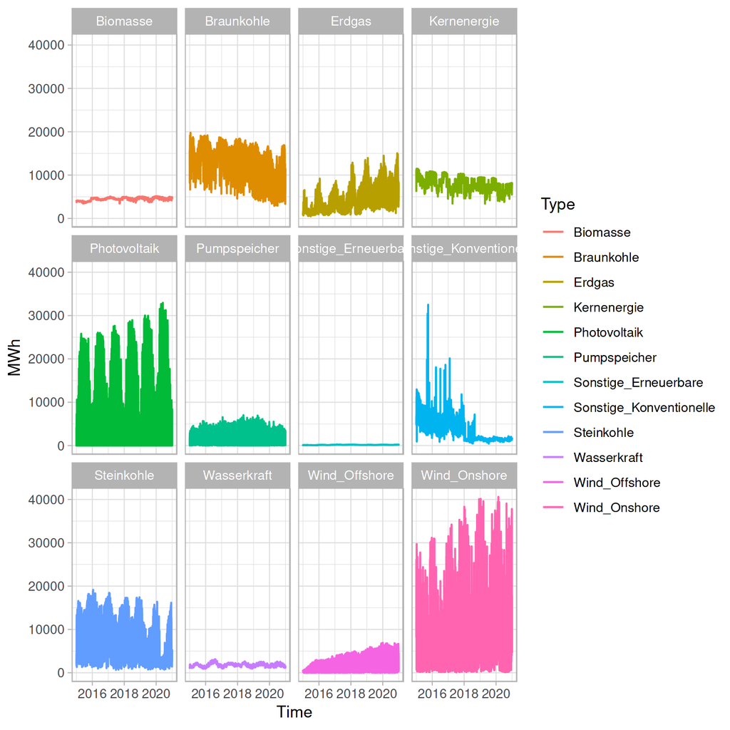

```r
ggplot(tidydf)+
    geom_line(aes(Time, MWh, color = Type)) + facet_wrap(Type~.)
```

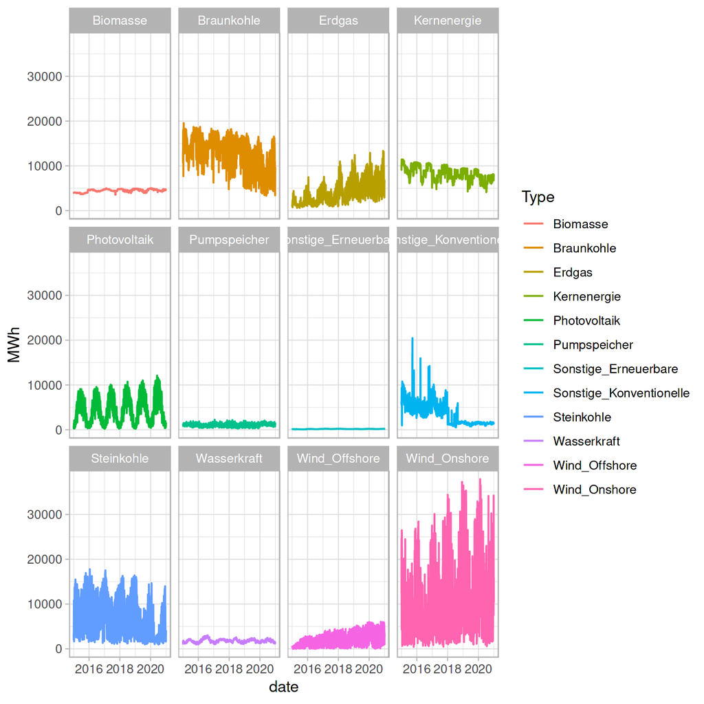

```r
tidydf %>%
            group_by(date = floor_date(Time, unit = "day"),Type) %>%
            summarize(MWh = mean(MWh)) %>%
            ggplot() + geom_line(aes(date,MWh,color = Type)) + facet_wrap(~Type)
```

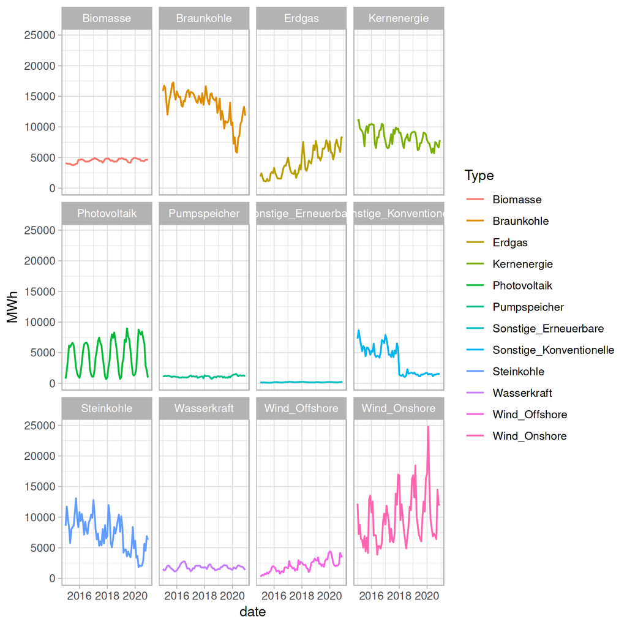

```r
tidydf %>%
            group_by(date = floor_date(Time, unit = "month"),Type) %>%
            summarize(MWh = mean(MWh)) %>%
            ggplot() + geom_line(aes(date,MWh,color = Type)) + facet_wrap(~Type)
            #identity
```

### Todos 3<sup>rd</sup> Session

- Select one of the types (e.g. Photovoltaik, Erdgas or Wind_Onshore)
- What kinds of seasonality are detectable?
- Is there a general trend on top of the seasonal pattern(s)?
- Can you use this information to manually craft a prediction model?

Bonus:

- How accurately does your manually created model predict the values in the validation set?

The following cell was generated by GPT-3.5 using this user prompt:

> load lubridate

```r
# Load the lubridate package
library(lubridate)
```

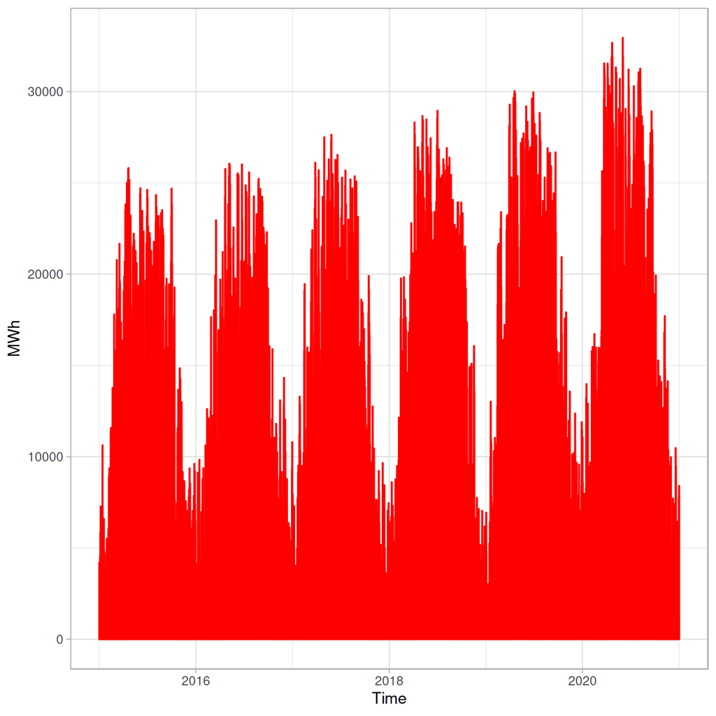

```r
tidydf %>% filter(Type == "Photovoltaik") %>%
ggplot()+
geom_line(aes(Time,MWh), color = "red")
```

```r
#winter = 12, 1, 2
#spring = 3, 4 ,5
#summer = 6, 7 ,8
#autumn = 9, 10, 11
```

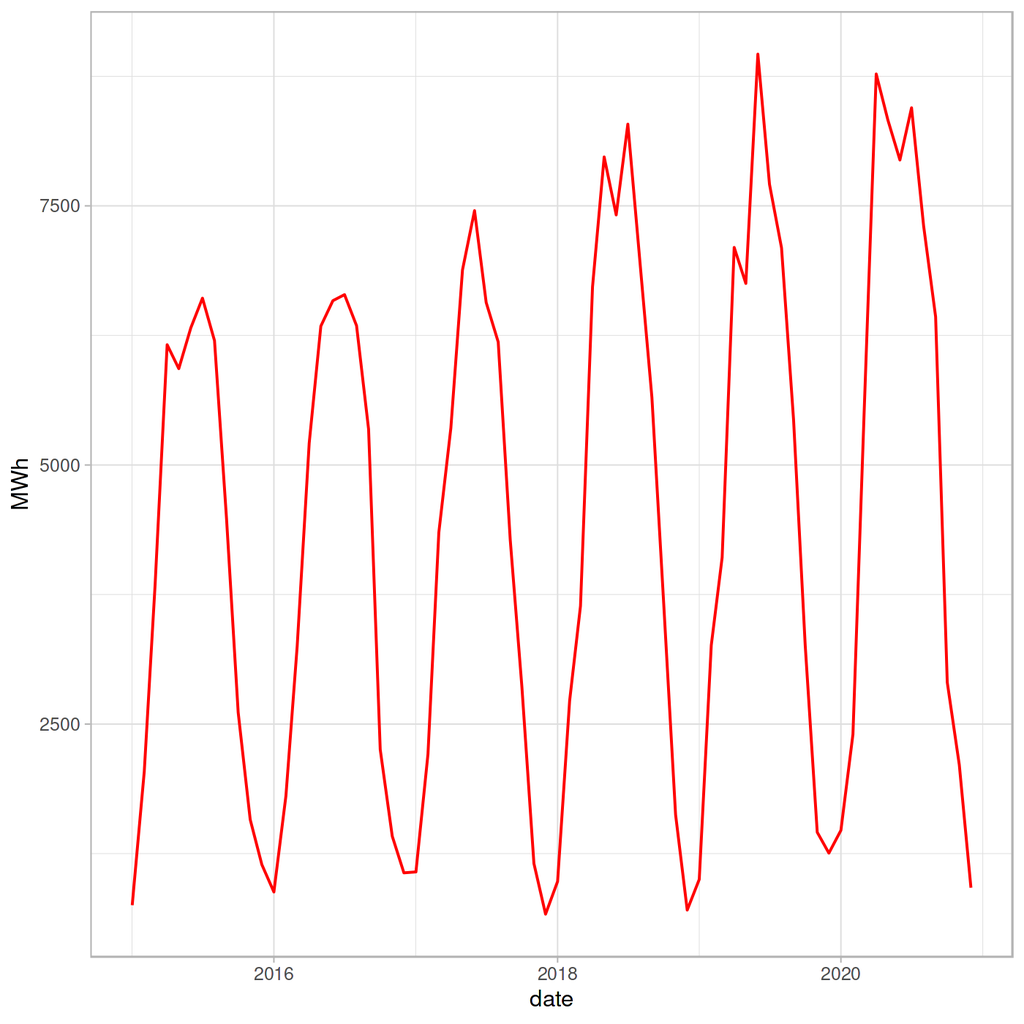

```r
tidydf %>% filter(Type == "Photovoltaik") %>%
group_by(date = floor_date(Time, unit = "month"),Type) %>%
            summarize(MWh = mean(MWh)) %>%
ggplot()+
geom_line(aes(date,MWh), color = "red")
```